# Self-Driving Car Engineer Nanodegree

## Project: Build a Traffic Sign Recognition Classifier

In this notebook, a template is provided for you to implement your functionality in stages, which is required to successfully complete this project. If additional code is required that cannot be included in the notebook, be sure that the Python code is successfully imported and included in your submission if necessary.

In addition to implementing code, there is a writeup to complete. The writeup should be completed in a separate file, which can be either a markdown file or a pdf document. There is a [write up template](https://github.com/udacity/CarND-Traffic-Sign-Classifier-Project/blob/master/writeup_template.md) that can be used to guide the writing process. Completing the code template and writeup template will cover all of the [rubric points](https://review.udacity.com/#!/rubrics/481/view) for this project.

The [rubric](https://review.udacity.com/#!/rubrics/481/view) contains "Stand Out Suggestions" for enhancing the project beyond the minimum requirements. The stand out suggestions are optional. If you decide to pursue the "stand out suggestions", you can include the code in this Ipython notebook and also discuss the results in the writeup file.

> **Note:** Code and Markdown cells can be executed using the **Shift + Enter** keyboard shortcut. In addition, Markdown cells can be edited by typically double-clicking the cell to enter edit mode.

## Step 0: Load The Data

```python
# Load pickled data
import pickle
import json
import numpy as np

# TODO: Fill this in based on where you saved the training and testing data
data_directory = "../traffic-signs-data/" # "../data"
training_file = data_directory + "train.p"
validation_file= data_directory + "valid.p"
testing_file = data_directory + "test.p"
signnames_file = "./signnames.csv"

with open(training_file, mode='rb') as f:
    train = pickle.load(f)
with open(validation_file, mode='rb') as f:
    valid = pickle.load(f)
with open(testing_file, mode='rb') as f:
    test = pickle.load(f)

# Get class names
signnames_dict = dict()
with open(signnames_file, mode='rb') as f:
    for cnt, _line in enumerate(f):
        if cnt == 0: # Note: data start from second line
            continue
        str_list = _line.decode().strip().split(",")
        # print(str_list)
        signnames_dict[int(str_list[0])] = str_list[1]

X_train, y_train = train['features'], train['labels']
X_valid, y_valid = valid['features'], valid['labels']
X_test, y_test = test['features'], test['labels']

print("signnames_dict = \n%s" % json.dumps(signnames_dict, indent=4))
```

```
signnames_dict =
{
    "0": "Speed limit (20km/h)",
    "1": "Speed limit (30km/h)",
    "2": "Speed limit (50km/h)",
    "3": "Speed limit (60km/h)",
    "4": "Speed limit (70km/h)",
    "5": "Speed limit (80km/h)",
    "6": "End of speed limit (80km/h)",
    "7": "Speed limit (100km/h)",
    "8": "Speed limit (120km/h)",
    "9": "No passing",
    "10": "No passing for vehicles over 3.5 metric tons",
    "11": "Right-of-way at the next intersection",
    "12": "Priority road",
    "13": "Yield",
    "14": "Stop",
    "15": "No vehicles",
    "16": "Vehicles over 3.5 metric tons prohibited",
    "17": "No entry",
    "18": "General caution",
    "19": "Dangerous curve to the left",
    "20": "Dangerous curve to the right",
    "21": "Double curve",
    "22": "Bumpy road",
    "23": "Slippery road",
    "24": "Road narrows on the right",
    "25": "Road work",
    "26": "Traffic signals",
    "27": "Pedestrians",
    "28": "Children crossing",
    "29": "Bicycles crossing",
    "30": "Beware of ice/snow",
    "31": "Wild animals crossing",
    "32": "End of all speed and passing limits",
    "33": "Turn right ahead",
    "34": "Turn left ahead",
    "35": "Ahead only",
    "36": "Go straight or right",
    "37": "Go straight or left",
    "38": "Keep right",
    "39": "Keep left",
    "40": "Roundabout mandatory",
    "41": "End of no passing",
    "42": "End of no passing by vehicles over 3.5 metric tons"
}
```

## Step 1: Dataset Summary & Exploration

The pickled data is a dictionary with 4 key/value pairs:

- `'features'` is a 4D array containing raw pixel data of the traffic sign images, (num examples, width, height, channels).
- `'labels'` is a 1D array containing the label/class id of the traffic sign. The file `signnames.csv` contains id -> name mappings for each id.
- `'sizes'` is a list containing tuples, (width, height) representing the original width and height the image.
- `'coords'` is a list containing tuples, (x1, y1, x2, y2) representing coordinates of a bounding box around the sign in the image. **THESE COORDINATES ASSUME THE ORIGINAL IMAGE. THE PICKLED DATA CONTAINS RESIZED VERSIONS (32 by 32) OF THESE IMAGES**

Complete the basic data summary below. Use python, numpy and/or pandas methods to calculate the data summary rather than hard coding the results. For example, the [pandas shape method](http://pandas.pydata.org/pandas-docs/stable/generated/pandas.DataFrame.shape.html) might be useful for calculating some of the summary results.

### Provide a Basic Summary of the Data Set Using Python, Numpy and/or Pandas

```python
### Replace each question mark with the appropriate value.
### Use python, pandas or numpy methods rather than hard coding the results

# TODO: Number of training examples
n_train = X_train.shape[0]

# TODO: Number of validation examples
n_validation = X_valid.shape[0]

# TODO: Number of testing examples.
n_test = X_test.shape[0]

# TODO: What's the shape of an traffic sign image?
image_shape = X_train[0].shape

# TODO: How many unique classes/labels there are in the dataset.
# n_classes = len(set(y_train))
n_classes = len(signnames_dict)

print("Shape of data set, X_train:%s" % str(X_train.shape))
print("Shape of labels, y_train:%s" % str(y_train.shape))
print("Number of training examples =", n_train)
print("Number of validation examples =", n_validation)
print("Number of testing examples =", n_test)
print("Image data shape =", image_shape)
print("Image data type = %s" % str(X_train[0].dtype))
print("Image data range (min, max) = (%s, %s)" % (np.min(X_train[0]), np.max(X_train[0])))
print("Number of classes =", n_classes)
```

```
Shape of data set, X_train:(34799, 32, 32, 3)
Shape of labels, y_train:(34799,)
Number of training examples = 34799
Number of validation examples = 4410
Number of testing examples = 12630
Image data shape = (32, 32, 3)
Image data type = uint8
Image data range (min, max) = (19, 113)
Number of classes = 43
```

### DataDistributions

```python
# Calculate the distribution of data set
def get_distribution(y_data, key_list):
    """
    """
    distribution_dict = dict()
    # Initialization
    for key in key_list:
        distribution_dict[key] = 0
    # Count
    for idx in range(len(y_data)):
        key = y_data[idx]
        value_pre = distribution_dict.get(key, 0)
        distribution_dict[key] = (value_pre+1)
    return distribution_dict
```

```python
import matplotlib.pyplot as plt
# Visualizations will be shown in the notebook.
%matplotlib inline

def plot_distribution(y_data, signnames_dict, title="Distribution"):
    key_list = sorted(signnames_dict.keys())
    distribution_dict = get_distribution(y_data, key_list)
    # Plot
    fig = plt.figure()
    ax = fig.add_axes([0,0,1,1])
    d_class = [signnames_dict[key] for key in key_list]
    d_count = [distribution_dict[key] for key in key_list]
    plt.xticks(rotation='vertical')
    plt.title(title)
    ax.bar(d_class,d_count)
    # Save the resulted figure
#     dir_out = "output_images/data_statistic/"
#     fig.savefig(dir_out + title + ".png")
    return distribution_dict
```

```
"Children crossing" in train/valid/test set: (480, 60, 150)
```

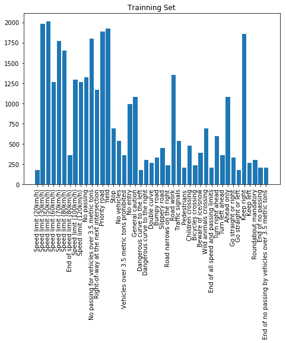

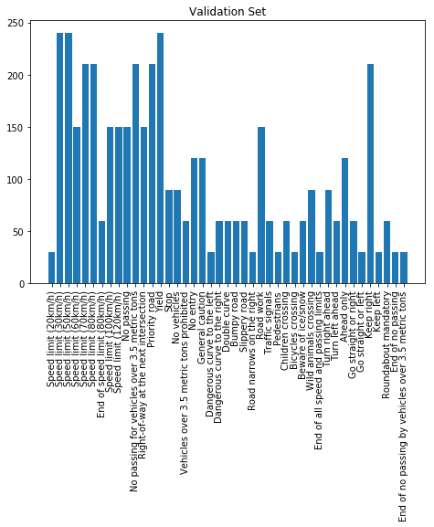

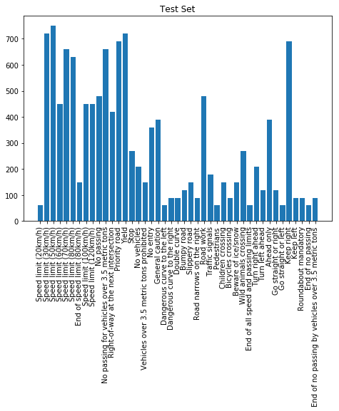

```python
distribution_train_dict = plot_distribution(y_train, signnames_dict, title="Trainning Set")
distribution_valid_dict = plot_distribution(y_valid, signnames_dict, title="Validation Set")
distribution_test_dict = plot_distribution(y_test, signnames_dict, title="Test Set")
#
idx = 28
print('"%s" in train/valid/test set: (%d, %d, %d)' % (signnames_dict[idx], distribution_train_dict[idx], distribution_valid_dict[idx], distribution_test_dict[idx]))
```

### Include an exploratory visualization of the dataset

Visualize the German Traffic Signs Dataset using the pickled file(s). This is open ended, suggestions include: plotting traffic sign images, plotting the count of each sign, etc.

The [Matplotlib](http://matplotlib.org/) [examples](http://matplotlib.org/examples/index.html) and [gallery](http://matplotlib.org/gallery.html) pages are a great resource for doing visualizations in Python.

**NOTE:** It's recommended you start with something simple first. If you wish to do more, come back to it after you've completed the rest of the sections. It can be interesting to look at the distribution of classes in the training, validation and test set. Is the distribution the same? Are there more examples of some classes than others?

```
Label=35:[Ahead only]
```

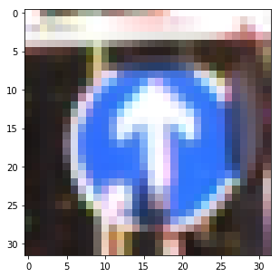

```python
### Data exploration visualization code goes here.
### Feel free to use as many code cells as needed.
import random
import matplotlib.pyplot as plt
# Visualizations will be shown in the notebook.
%matplotlib inline

index = random.randint(0, len(X_train))
# image = X_train[index].squeeze()
image = X_train[index]

plt.figure(figsize=(5,5))
plt.imshow(image)
print('Label=%d:[%s]' % (y_train[index], signnames_dict[y_train[index]]) )
```

## Step 2: Design and Test a Model Architecture

Design and implement a deep learning model that learns to recognize traffic signs. Train and test your model on the [German Traffic Sign Dataset](http://benchmark.ini.rub.de/?section=gtsrb&subsection=dataset).

The LeNet-5 implementation shown in the classroom at the end of the CNN lesson is a solid starting point. You'll have to change the number of classes and possibly the preprocessing, but aside from that it's plug and play!

With the LeNet-5 solution from the lecture, you should expect a validation set accuracy of about 0.89. To meet specifications, the validation set accuracy will need to be at least 0.93. It is possible to get an even higher accuracy, but 0.93 is the minimum for a successful project submission.

There are various aspects to consider when thinking about this problem:

- Neural network architecture (is the network over or underfitting?)
- Play around preprocessing techniques (normalization, rgb to grayscale, etc)
- Number of examples per label (some have more than others).
- Generate fake data.

Here is an example of a [published baseline model on this problem](http://yann.lecun.com/exdb/publis/pdf/sermanet-ijcnn-11.pdf). It's not required to be familiar with the approach used in the paper but, it's good practice to try to read papers like these.

### Pre-process the Data Set (normalization, grayscale, etc.)

Minimally, the image data should be normalized so that the data has mean zero and equal variance. For image data, `(pixel - 128)/ 128` is a quick way to approximately normalize the data and can be used in this project.

Other pre-processing steps are optional. You can try different techniques to see if it improves performance.

Use the code cell (or multiple code cells, if necessary) to implement the first step of your project.

```python
### Preprocess the data here. It is required to normalize the data. Other preprocessing steps could include
### converting to grayscale, etc.
### Feel free to use as many code cells as needed.
from sklearn.utils import shuffle

# X_train, y_train = shuffle(X_train, y_train)
```

```python
def pre_processing(a_single_x):
    """
    This processing is for every single data.
    Note: I don't process all data at once because
           there might have some adaptive function in preprocessing
           which is different for different input data.
    """
    # a_single_x_modified = a_single_x
    # a_single_x_modified = (a_single_x -128)/128 # Note: This only work for floating point data
    # Normalize data for chart
#     x_min, x_max = np.min(a_single_x), np.max(a_single_x)
    br = 5
    x_min, x_max = np.min(a_single_x[br:-br:]), np.max(a_single_x[br:-br:])
    a_single_x_modified = np.clip( (a_single_x.astype(np.float32) - x_min) * (255.0/(x_max-x_min)), 0.0, 255.0 ).astype(np.uint8)
    return a_single_x_modified

# def pre_processing(a_single_x):
#     """
#     This processing is for every single data.
#     Note: I don't process all data at once because
#            there might have some adaptive function in preprocessing
#            which is different for different input data.
#     """
#     # a_single_x_modified = a_single_x
#     # a_single_x_modified = (a_single_x -128)/128 # Note: This only work for floating point data
#     # Normalize data for chart
# #     x_min, x_max = np.min(a_single_x), np.max(a_single_x)
#     br = 5
#     x_mean, x_var = np.mean(a_single_x[br:-br:], dtype=np.float32), np.var(a_single_x[br:-br:], dtype=np.float32)
#     ratio = 127.0/(x_var**0.5)
#     a_single_x_modified = np.clip( (a_single_x.astype(np.float32) - x_mean) * ratio + 127.0, 0.0, 255.0 ).astype(np.uint8)
#     return a_single_x_modified
```

```python
def pre_processing_all_data(X_data):
    """
    Apply the preporcessing on every x
    """
    X_data_modified = X_data.copy()
    for idx in range(len(X_data)):
        X_data_modified[idx] = pre_processing(X_data[idx])
    return X_data_modified
```

```python
X_train_m = pre_processing_all_data(X_train)
X_valid_m = pre_processing_all_data(X_valid)
X_test_m = pre_processing_all_data(X_test)
```

```
index = 18828
Label=10:[No passing for vehicles over 3.5 metric tons]
Image data type = uint8
Image data range (min, max) = (6, 33)
image_m data type = uint8
image_m data range (min, max) = (0, 255)
```

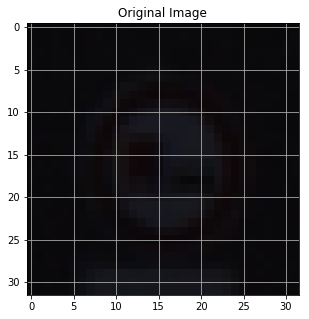

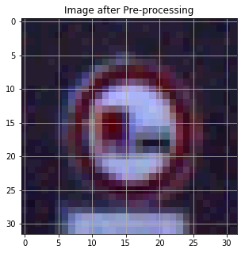

```python
dir_out = "output_images/data_visualizations/"

# Visualize the data again
index = random.randint(0, len(X_train))

index = 18828 # Large change
# index = 24974 # Midium-high change
# index = 24773 # Midium-low change
# index = 8010 # Less change

# index = 25735 # Fail to fix the sign due to high-value-range background
# index = 1188 # Fail to fix the sign due to high-value-range background


image = X_train[index]
image_m = X_train_m[index]


#
print("index = %d" % index)
print('Label=%d:[%s]' % (y_train[index], signnames_dict[y_train[index]]) )
print("Image data type = %s" % str(image.dtype))
print("Image data range (min, max) = (%s, %s)" % (np.min(image), np.max(image)))
print("image_m data type = %s" % str(image_m.dtype))
print("image_m data range (min, max) = (%s, %s)" % (np.min(image_m), np.max(image_m)))


plt.figure(figsize=(5,5))
plt.title("Original Image")
plt.imshow(image)
plt.grid()
# Save the resulted figure
plt.savefig(dir_out + "plot_image_original.png")

plt.figure(figsize=(5,5))
plt.title("Image after Pre-processing")
plt.imshow(image_m)
plt.grid()
# Save the resulted figure
plt.savefig(dir_out + "plot_image_preprocessed.png")
```

## Data Augmentation

```python
def get_inverse_probability_distribution(distribution_dict):
    """
    """
    inv_distribution_dict = dict()
    total_ = 0.0
    for key in distribution_dict:
        inv_distribution_dict[key] = 1.0/distribution_dict[key]
        total_ += inv_distribution_dict[key]
    for key in inv_distribution_dict:
        inv_distribution_dict[key] /= total_
    return inv_distribution_dict

def get_sample_probalistic_list(y_data, distribution_dict, inv_distribution_dict=None):
    """
    """
    if inv_distribution_dict is None:
        inv_distribution_dict = get_inverse_probability_distribution(distribution_dict)
    p_list = list()
    for idx in range(len(y_data)):
        p_list.append( inv_distribution_dict[y_data[idx]]/distribution_dict[y_data[idx]] )
    return p_list

# def get_array_like_dataset(X_data):
#     """
#     """
#     X_list = list()
#     for idx in range(len(X_data)):
#         X_list.append(X_data[idx])
#     return X_list

def resample_dataset(X_data, y_data, p_list=None, num_sample=None):
    """
    """
    if p_list is None:
        return shuffle(X_data, y_data)
    # else
    if num_sample is None:
        num_sample = len(X_data)
    idx_resample = np.array(np.random.choice(len(X_data), size=num_sample, p=p_list))
    return X_data[idx_resample], y_data[idx_resample]
```

```
<BarContainer object of 43 artists>
```

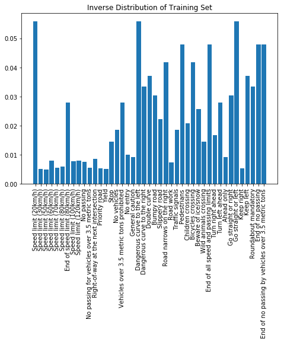

```python
inv_distribution_train_dict = get_inverse_probability_distribution(distribution_train_dict)
p_train_list = get_sample_probalistic_list(y_train, distribution_train_dict)
# X_train_list = get_array_like_dataset(X_train)

# Plot
key_list = sorted(signnames_dict.keys())
title = "Inverse Distribution of Training Set"
fig = plt.figure()
ax = fig.add_axes([0,0,1,1])
d_class = [signnames_dict[key] for key in key_list]
d_count = [inv_distribution_train_dict[key] for key in key_list]
plt.xticks(rotation='vertical')
plt.title(title)
ax.bar(d_class,d_count)
```

```python
import imgaug.augmenters as iaa
def generate_augmentations(data_in, label_in):
    """
    """
    data_aug = list()
    label_aug = list()
    rotate_op = iaa.Affine(rotate=(-30, 30)) # -30 to 30
    noise_op = iaa.AdditiveGaussianNoise(10,20)
    crop_op = iaa.Crop(percent=(0.3, 0.3)) # 30%
    scale_op = iaa.Affine(scale={"x": (1.2, 0.8), "y": (1.2, 0.8)})
    for idx in range(len(data_in)):
        data_aug.append( data_in[idx] )
        label_aug.append( label_in[idx])
        #
#         data_aug.append( rotate_op.augment_image(data_in[idx]) )
#         label_aug.append( label_in[idx])
#         data_aug.append( noise_op.augment_image(data_in[idx]) )
#         label_aug.append( label_in[idx])
#         data_aug.append( crop_op.augment_image(data_in[idx]) )
#         label_aug.append( label_in[idx])
#         data_aug.append( scale_op.augment_image(data_in[idx]) )
#         label_aug.append( label_in[idx])
        #
        data_fake = noise_op.augment_image(data_in[idx])
#         data_fake = rotate_op.augment_image(data_fake)
        data_fake = scale_op.augment_image(data_fake)
#         data_fake = crop_op.augment_image(data_fake)
        data_aug.append( data_fake )
        label_aug.append( label_in[idx])

    return np.array(data_aug), np.array(label_aug)
```

```python
# X_train_m, y_train = generate_augmentations(X_train_m, y_train)
```

### Model Architecture

**Setup TensorFlow**

The `EPOCH` and `BATCH_SIZE` values affect the training speed and model accuracy.

You do not need to modify this section.

```python
import tensorflow as tf
from tqdm import tqdm
import math
```

## Implement NN based on LeNet-5

Implement the [LeNet-5](http://yann.lecun.com/exdb/lenet/) neural network architecture.

This is the only cell you need to edit.

### Architecture

**Activation.** Your choice of activation function.

**Activation.** Your choice of activation function.

**Flatten.** Flatten the output shape of the final pooling layer such that it's 1D instead of 3D. The easiest way to do is by using `tf.contrib.layers.flatten`, which is already imported for you.

**Layer 3: Fully Connected.** This should have 120 outputs.

**Activation.** Your choice of activation function.

**Layer 4: Fully Connected.** This should have 84 outputs.

**Activation.** Your choice of activation function.

```python
import math

def get_conv_out_size(in_size, f_size=5, stride=1, padding="VALID"):
    """
    """
    if padding == "VALID":
        return math.ceil(float(in_size - f_size + 1) / float(stride))
    else:
        return math.ceil(float(in_size) / float(stride))
```

```python
### Define your architecture here.
### Feel free to use as many code cells as needed.
from tensorflow.contrib.layers import flatten

# The number of input channel
input_image_chanel = 3

def NN_sign(x, keep_prob):
    # Arguments used for tf.truncated_normal, randomly defines variables for the weights and biases for each layer
    mu = 0.0
    sigma = 0.1

    padding_method = "VALID"
#     padding_method = "SAME"
    # Parameters
    size_f1 = 3 # 5
    num_feature_f1 = 16 # 10 # 6
    size_f2 = 3 # 5
    num_feature_f2 = 30 # 16
    relu_leak_slope = 0.2

    #---------#
    s_1 = get_conv_out_size(32, f_size=size_f1, stride=1, padding=padding_method) # conv1
    s_1 = get_conv_out_size(s_1, f_size=2, stride=2, padding=padding_method) # pooling
    s_1 = get_conv_out_size(s_1, f_size=size_f2, stride=1, padding=padding_method) # conv2
    s_1 = get_conv_out_size(s_1, f_size=2, stride=2, padding=padding_method) # pooling
    conv_2_total_param_out = (s_1**2)*num_feature_f2
    print("Output size of conv2_pool = %d" % s_1)
    #---------#

    # Store layers weight & bias
    weights = {
        'wc1': tf.Variable(tf.truncated_normal([size_f1, size_f1, input_image_chanel, num_feature_f1], mean=mu, stddev=sigma)),
        'wc2': tf.Variable(tf.truncated_normal([size_f2, size_f2, num_feature_f1, num_feature_f2], mean=mu, stddev=sigma)),
        'wd1': tf.Variable(tf.truncated_normal([conv_2_total_param_out, 120], mean=mu, stddev=sigma)),
        'wd2': tf.Variable(tf.truncated_normal([120, 84], mean=mu, stddev=sigma)),
        'out': tf.Variable(tf.truncated_normal([84, n_classes], mean=mu, stddev=sigma))}

    biases = {
        'bc1': tf.Variable(tf.truncated_normal([num_feature_f1], mean=1.0, stddev=sigma*127)),
        'bc2': tf.Variable(tf.truncated_normal([num_feature_f2], mean=mu, stddev=sigma)),
        'bd1': tf.Variable(tf.truncated_normal([120], mean=mu, stddev=sigma)),
        'bd2': tf.Variable(tf.truncated_normal([84], mean=mu, stddev=sigma)),
        'out': tf.Variable(tf.truncated_normal([n_classes], mean=mu, stddev=sigma))}



    #-----------------#

    # Step 1: Convert the input image from uint8 to float32
    # x_float = tf.image.convert_image_dtype(x, tf.float32, saturate=False)
    x_float = tf.cast(x, tf.float32)

    # Layer 1: Convolutional. Input = 32x32x1. Output = 28x28x6.
    conv1 = tf.nn.conv2d(x_float, weights['wc1'], strides=[1, 1, 1, 1], padding=padding_method)
    conv1 = tf.nn.bias_add(conv1, biases['bc1'])

    # Activation.
#     conv1_a = tf.nn.relu(conv1)
    conv1_a = tf.nn.leaky_relu(conv1, alpha=relu_leak_slope)
#     conv1_a = tf.nn.dropout(conv1_a, keep_prob)

    # Pooling. Input = 28x28x6. Output = 14x14x6.
    conv1_pool = tf.nn.max_pool(conv1_a, ksize=[1, 2, 2, 1], strides=[1, 2, 2, 1], padding=padding_method)

    # Layer 2: Convolutional. Output = 10x10x16.
    conv2 = tf.nn.conv2d(conv1_pool, weights['wc2'], strides=[1, 1, 1, 1], padding=padding_method)
    conv2 = tf.nn.bias_add(conv2, biases['bc2'])

    # Activation.
#     conv2_a = tf.nn.relu(conv2)
    conv2_a = tf.nn.leaky_relu(conv2, alpha=relu_leak_slope)
#     conv2_a = tf.nn.dropout(conv2_a, keep_prob)

    # Pooling. Input = 10x10x16. Output = 5x5x16.
    conv2_pool = tf.nn.max_pool(conv2_a, ksize=[1, 2, 2, 1], strides=[1, 2, 2, 1], padding=padding_method)

    # TODO: Flatten. Input = 5x5x16. Output = 400.
    # fc0 = tf.reshape(conv2_pool, [-1, weights['wd1'].get_shape().as_list()[0]])
    fc0   = flatten(conv2_pool)

    # TODO: Layer 3: Fully Connected. Input = 400. Output = 120.
    fc1 = tf.add(tf.matmul(fc0, weights['wd1']), biases['bd1'])

    # TODO: Activation.
#     fc1_a = tf.nn.relu(fc1)
    fc1_a = tf.nn.leaky_relu(fc1, alpha=relu_leak_slope)
    fc1_a = tf.nn.dropout(fc1_a, keep_prob)

    # TODO: Layer 4: Fully Connected. Input = 120. Output = 84.
    fc2 = tf.add(tf.matmul(fc1_a, weights['wd2']), biases['bd2'])

    # TODO: Activation.
#     fc2_a = tf.nn.relu(fc2)
    fc2_a = tf.nn.leaky_relu(fc2, alpha=relu_leak_slope)
    fc2_a = tf.nn.dropout(fc2_a, keep_prob)

    # TODO: Layer 5: Fully Connected. Input = 84. Output = 10.
    logits = tf.add(tf.matmul(fc2_a, weights['out']), biases['out'])

    # Regulizer
#     regularizer = tf.nn.l2_loss(weights['wc1'])
#     regularizer = tf.add( regularizer, tf.nn.l2_loss(weights['wc2']) )
#     regularizer = tf.add( regularizer, tf.nn.l2_loss(weights['wd1']) )
#     regularizer = tf.add( regularizer, tf.nn.l2_loss(weights['wd2']) )
#     regularizer = tf.add( regularizer, tf.nn.l2_loss(weights['out']) )
    regularizer = tf.nn.l2_loss(weights['out'])


    layer_dict = dict()
    layer_dict["conv1"] = conv1
    layer_dict["conv1_a"] = conv1_a
    layer_dict["conv1_pool"] = conv1_pool
    layer_dict["conv2"] = conv2
    layer_dict["conv2_a"] = conv2_a
    layer_dict["conv2_pool"] = conv2_pool
    layer_dict["fc0"] = fc0
    layer_dict["fc1"] = fc1
    layer_dict["fc1_a"] = fc1_a
    layer_dict["fc2"] = fc2
    layer_dict["fc2_a"] = fc2_a
    layer_dict["logits"] = logits
    layer_dict["regularizer"] = regularizer

    return layer_dict
```

### Train, Validate and Test the Model

A validation set can be used to assess how well the model is performing. A low accuracy on the training and validation sets imply underfitting. A high accuracy on the training set but low accuracy on the validation set implies overfitting.

```python
### Train your model here.
### Calculate and report the accuracy on the training and validation set.
### Once a final model architecture is selected,
### the accuracy on the test set should be calculated and reported as well.
### Feel free to use as many code cells as needed.
```

**Features and Labels**

`x` is a placeholder for a batch of input images. `y` is a placeholder for a batch of output labels.

You do not need to modify this section.

```python
x = tf.placeholder(tf.uint8, (None, 32, 32, input_image_chanel))
y = tf.placeholder(tf.int32, (None))

# Generate the one-hot version of y
one_hot_y = tf.one_hot(y, n_classes)
```

Hyper parameters:

```python
# Create Model with Dropout
keep_prob = tf.placeholder(tf.float32) # probability to keep units
# learning_rate
learning_rate = tf.placeholder(tf.float32) #
```

**Training Pipeline**

You do not need to modify this section.

```python
rate = learning_rate # 0.001
beta = 0.2 # 0.01

layer_dict = NN_sign(x, keep_prob=keep_prob)
# NN output
# cross entropy
cross_entropy = tf.nn.softmax_cross_entropy_with_logits(labels=one_hot_y, logits=layer_dict["logits"])
# The loss
# loss_operation = tf.reduce_mean(cross_entropy)
loss_operation = tf.reduce_mean(cross_entropy + beta * layer_dict["regularizer"])
#
optimizer = tf.train.AdamOptimizer(learning_rate = rate)
training_operation = optimizer.minimize(loss_operation)
```

[output not shown]

**Model Evaluation**

Evaluate how well the loss and accuracy of the model for a given dataset.

You do not need to modify this section.

```python
correct_prediction = tf.equal(tf.argmax(layer_dict["logits"], 1), tf.argmax(one_hot_y, 1))
accuracy_operation = tf.reduce_mean(tf.cast(correct_prediction, tf.float32))

def evaluate(X_data, y_data, keep_prob_value=1.0):
    num_examples = len(X_data)
    total_accuracy = 0
    sess = tf.get_default_session()
    for offset in range(0, num_examples, BATCH_SIZE):
        batch_x, batch_y = X_data[offset:offset+BATCH_SIZE], y_data[offset:offset+BATCH_SIZE]
        accuracy = sess.run(accuracy_operation, feed_dict={x: batch_x, y: batch_y, keep_prob:keep_prob_value})
        total_accuracy += (accuracy * len(batch_x))
    return total_accuracy / num_examples
```

**Train the Model**

Run the training data through the training pipeline to train the model.

Before each epoch, shuffle the training set.

After each epoch, measure the loss and accuracy of the validation set.

Save the model after training.

You do not need to modify this section.

```python
# Hyper parameters
EPOCHS = 30 # 10
BATCH_SIZE = 128
```

```
Training...
```

```
EPOCH 1 ...
Last Batch Accuracy = 0.694
Validation Accuracy = 0.549
```

```
EPOCH 2 ...
Last Batch Accuracy = 0.811
Validation Accuracy = 0.770
```

```
EPOCH 3 ...
Last Batch Accuracy = 0.928
Validation Accuracy = 0.823
```

```
EPOCH 4 ...
Last Batch Accuracy = 0.973
Validation Accuracy = 0.858
```

```
EPOCH 5 ...
Last Batch Accuracy = 0.982
Validation Accuracy = 0.908
```

```
EPOCH 6 ...
Last Batch Accuracy = 0.937
Validation Accuracy = 0.911
```

```
EPOCH 7 ...
Last Batch Accuracy = 0.964
Validation Accuracy = 0.927
```

```
EPOCH 8 ...
Last Batch Accuracy = 0.973
Validation Accuracy = 0.939
```

```
EPOCH 9 ...
Last Batch Accuracy = 0.991
Validation Accuracy = 0.938
```

```
EPOCH 10 ...
Last Batch Accuracy = 0.982
Validation Accuracy = 0.952
```

```
Whole Traning Set Accuracy = 0.990
```

```
EPOCH 11 ...
Last Batch Accuracy = 1.000
Validation Accuracy = 0.949
```

```
EPOCH 12 ...
Last Batch Accuracy = 1.000
Validation Accuracy = 0.956
```

```
EPOCH 13 ...
Last Batch Accuracy = 0.991
Validation Accuracy = 0.956
```

```
EPOCH 14 ...
Last Batch Accuracy = 1.000
Validation Accuracy = 0.956
```

```
EPOCH 15 ...
Last Batch Accuracy = 1.000
Validation Accuracy = 0.963
```

```
EPOCH 16 ...
Last Batch Accuracy = 1.000
Validation Accuracy = 0.959
```

```
EPOCH 17 ...
Last Batch Accuracy = 1.000
Validation Accuracy = 0.964
```

```
EPOCH 18 ...
Last Batch Accuracy = 1.000
Validation Accuracy = 0.960
```

```
EPOCH 19 ...
Last Batch Accuracy = 1.000
Validation Accuracy = 0.957
```

```
EPOCH 20 ...
Last Batch Accuracy = 0.991
Validation Accuracy = 0.961
```

```
Whole Traning Set Accuracy = 0.996
```

```
EPOCH 21 ...
Last Batch Accuracy = 1.000
Validation Accuracy = 0.958
```

```
EPOCH 22 ...
Last Batch Accuracy = 1.000
Validation Accuracy = 0.967
```

```
EPOCH 23 ...
Last Batch Accuracy = 0.982
Validation Accuracy = 0.967
```

```
EPOCH 24 ...
Last Batch Accuracy = 1.000
Validation Accuracy = 0.955
```

```
EPOCH 25 ...
Last Batch Accuracy = 1.000
Validation Accuracy = 0.970
```

```
EPOCH 26 ...
Last Batch Accuracy = 1.000
Validation Accuracy = 0.967
```

```
EPOCH 27 ...
Last Batch Accuracy = 1.000
Validation Accuracy = 0.966
```

```
EPOCH 28 ...
Last Batch Accuracy = 0.991
Validation Accuracy = 0.970
```

```
EPOCH 29 ...
Last Batch Accuracy = 1.000
Validation Accuracy = 0.964
```

```
EPOCH 30 ...
Last Batch Accuracy = 1.000
Validation Accuracy = 0.961
Whole Traning Set Accuracy = 0.998

Model saved
```

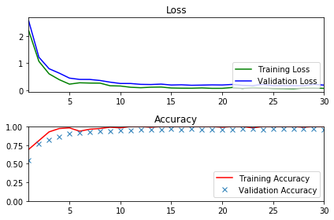

```
Training accuracy at 0.99821833960746
Validation accuracy at 0.9614512469222486
```

```python
X_train_in, y_train_in = X_train_m, y_train
X_valid_in, y_valid_in = X_valid_m, y_valid

# Measurements use for graphing loss and accuracy
epochs_num = []
loss_batch = []
loss_valid = []
train_acc_batch = []
valid_acc_batch = []

LEARNING_RATE_HIGH = 0.0018
LEARNING_RATE_MID = 0.0008
LEARNING_RATE_LOW = 0.0005
learning_rate_now = LEARNING_RATE_HIGH

# Random seed
tf.set_random_seed(220)

#
last_batch_accuracy = 0.0
validation_accuracy = 0.0

# Model saver
saver = tf.train.Saver()

# with tf.Session() as sess:
with tf.Session(config=tf.ConfigProto(log_device_placement=True)) as sess:
    sess.run(tf.global_variables_initializer())


    print("Training...")
    print()
    for epoch_i in range(EPOCHS):
        # Decide which learning rate to be used
        learning_rate_now = LEARNING_RATE_HIGH if last_batch_accuracy < 0.97 else LEARNING_RATE_MID
        learning_rate_now = LEARNING_RATE_LOW if last_batch_accuracy >= 0.995 else learning_rate_now

        # Shuffle the training data per epoch
        # X_train_s, y_train_s = shuffle(X_train_in, y_train_in)
        X_train_s, y_train_s = resample_dataset(X_train_in, y_train_in) # The same as shuffle()
#         X_train_s, y_train_s = resample_dataset(X_train_in, y_train_in, p_list=p_train_list, num_sample=len(X_train_in))

        # num_examples = len(X_train_s)

        batch_count = int(math.ceil(float(len(X_train_s))/BATCH_SIZE))
        # Progress bar
        batches_pbar = tqdm(range(batch_count), desc='Epoch {:>2}/{}'.format(epoch_i+1, EPOCHS), unit='batches')

        # The training cycle
        # for offset in range(0, num_examples, BATCH_SIZE):
        for batch_i in batches_pbar:
            # Get a batch of training features and labels
            offset = batch_i*BATCH_SIZE
            end = offset + BATCH_SIZE
            #
            batch_x, batch_y = X_train_s[offset:end], y_train_s[offset:end]
#             batch_x, batch_y = generate_augmentations(batch_x, batch_y) # On-line data augmentation
            sess.run(training_operation, feed_dict={x: batch_x, y: batch_y, keep_prob:0.5, learning_rate:learning_rate_now})

        last_batch_loss = sess.run(loss_operation, feed_dict={x:batch_x, y:batch_y, keep_prob:1.0})
        valid_loss = sess.run(loss_operation, feed_dict={x:X_valid_in, y:y_valid_in, keep_prob:1.0})

        last_batch_accuracy = evaluate(batch_x, batch_y, keep_prob_value=1.0)
        validation_accuracy = evaluate(X_valid_in, y_valid_in, keep_prob_value=1.0)
        print("EPOCH {} ...".format(epoch_i+1))
        print("Last Batch Accuracy = {:.3f}".format(last_batch_accuracy))
        print("Validation Accuracy = {:.3f}".format(validation_accuracy))
        if (epoch_i == EPOCHS-1) or ((epoch_i+1)%10==0 and epoch_i!=0):
            training_accuracy = evaluate(X_train_s, y_train_s, keep_prob_value=1.0)
            print("Whole Traning Set Accuracy = {:.3f}".format(training_accuracy))
        print()

        # Log every epoch
        previous_epoch = epochs_num[-1] if epochs_num else 0
        epochs_num.append(1 + previous_epoch)
        loss_batch.append(last_batch_loss)
        loss_valid.append(valid_loss)
        train_acc_batch.append(last_batch_accuracy)
        valid_acc_batch.append(validation_accuracy)



    saver.save(sess, './lenet')
    print("Model saved")


loss_plot = plt.subplot(211)
loss_plot.set_title('Loss')
loss_plot.plot(epochs_num, loss_batch, 'g', label='Training Loss')
loss_plot.plot(epochs_num, loss_valid, 'b', label='Validation Loss')
loss_plot.legend(loc=4)
loss_plot.set_xlim([epochs_num[0], epochs_num[-1]])

acc_plot = plt.subplot(212)
acc_plot.set_title('Accuracy')
acc_plot.plot(epochs_num, train_acc_batch, 'r', label='Training Accuracy')
acc_plot.plot(epochs_num, valid_acc_batch, 'x', label='Validation Accuracy')
acc_plot.set_ylim([0, 1.0])
acc_plot.set_xlim([epochs_num[0], epochs_num[-1]])
acc_plot.legend(loc=4)
plt.tight_layout()
plt.show()

print('Training accuracy at {}'.format(training_accuracy))
print('Validation accuracy at {}'.format(validation_accuracy))
```

**Evaluate the Model**

Once you are completely satisfied with your model, evaluate the performance of the model on the test set.

Be sure to only do this once!

If you were to measure the performance of your trained model on the test set, then improve your model, and then measure the performance of your model on the test set again, that would invalidate your test results. You wouldn't get a true measure of how well your model would perform against real data.

You do not need to modify this section.

```python
X_test_in, y_test_in = X_test_m, y_test

with tf.Session() as sess:
    saver.restore(sess, tf.train.latest_checkpoint('.'))

    test_accuracy = evaluate(X_test_in, y_test_in)
    print("Test Accuracy = {:.3f}".format(test_accuracy))
```

```
WARNING:tensorflow:From /home/itri/.local/lib/python3.5/site-packages/tensorflow/python/training/saver.py:1276: checkpoint_exists (from tensorflow.python.training.checkpoint_management) is deprecated and will be removed in a future version.
Instructions for updating:
Use standard file APIs to check for files with this prefix.
INFO:tensorflow:Restoring parameters from ./lenet
Test Accuracy = 0.945
```

## Step 3: Test a Model on New Images

To give yourself more insight into how your model is working, download at least five pictures of German traffic signs from the web and use your model to predict the traffic sign type.

You may find `signnames.csv` useful as it contains mappings from the class id (integer) to the actual sign name.

### Load and Output the Images

```python
### Load the images and plot them here.
### Feel free to use as many code cells as needed.
# import glob
import matplotlib.image as mpimg
import cv2
import glob
import os

#-----------#
dir_in = "test_images/"
# test_images = glob.glob(dir_in + "/test_*.jpg")
test_images = [dir_in + "test_%d.jpg" % idx for idx in [1,2,4,5,7] ]
img_dict = dict()
for fpath in test_images:
    fdir, fname = os.path.split(fpath)
    img_dict[fname] = mpimg.imread(fpath) # Read image from disk
```

```python
# Labels
label_dict = dict()
label_dict["test_1.jpg"] = 28
label_dict["test_2.jpg"] = 28
label_dict["test_3.jpg"] = 28
label_dict["test_4.jpg"] = 28
label_dict["test_5.jpg"] = 28
label_dict["test_6.jpg"] = 28
label_dict["test_7.jpg"] = 28
```

```
img_dict_key = ['test_1.jpg', 'test_2.jpg', 'test_4.jpg', 'test_5.jpg', 'test_7.jpg']
```

[figure not shown]

[figure not shown]

[figure not shown]

[figure not shown]

[figure not shown]

```python
# Show all the intermediate images in pipeline
#-------------------------------------------------#
img_dict_key= sorted(list(img_dict.keys()))
print("img_dict_key = %s" % str(img_dict_key))
fig_id = 0
for fig_id in range(len(img_dict_key)):
    plt.figure(fig_id)
    plt.title("Fig. %d %s" % (fig_id, str(img_dict_key[fig_id])))
    plt.imshow(img_dict[img_dict_key[fig_id]], cmap='gray')
```

```python
def get_correct_size_image(img_ori, ROI):
    img_crop = img_ori[ROI[1]:(ROI[1]+ROI[3]), ROI[0]:(ROI[0]+ROI[2])]
    return cv2.resize(img_crop, dsize=(32, 32), interpolation=cv2.INTER_AREA) # cv2.INTER_AREA: better for down sampling
```

```python
# Define ROIs
# ROI = [x1, y1, width, height]
ROI_dict = dict()
ROI_dict["test_1.jpg"] = [150, 0, 850, 850]
ROI_dict["test_2.jpg"] = [600, 0, 580, 580]
ROI_dict["test_3.jpg"] = [420, 0, 800, 800]
ROI_dict["test_4.jpg"] = [300, 300, 320, 320]
ROI_dict["test_5.jpg"] = [0, 0, 830, 830]
ROI_dict["test_6.jpg"] = [200, 0, 800, 800]
ROI_dict["test_7.jpg"] = [100, 0, 700, 700]

# img_x_dict is the dict for images corrected image for input to network
img_x_dict = dict()
for key in img_dict:
    # img_x_dict[key] = get_correct_size_image(img_dict[key], ROI_dict[key])
    img_x_dict[key] = pre_processing( get_correct_size_image(img_dict[key], ROI_dict[key])  )
    # print(img_x_dict[key].dtype)
```

```
img_dict_key = ['test_1.jpg', 'test_2.jpg', 'test_4.jpg', 'test_5.jpg', 'test_7.jpg']
```

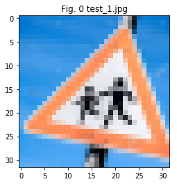

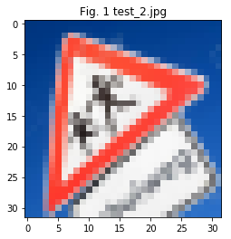

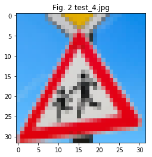

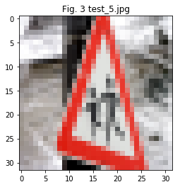

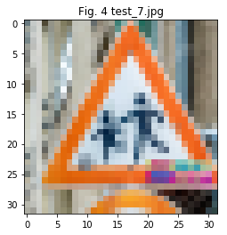

```python
# Show all the intermediate images in pipeline
#-------------------------------------------------#
img_dict_key= sorted(list(img_dict.keys()))
print("img_dict_key = %s" % str(img_dict_key))
fig_id = 0
for fig_id in range(len(img_dict_key)):
    plt.figure(fig_id)
    plt.title("Fig. %d %s" % (fig_id, str(img_dict_key[fig_id])))
    plt.imshow(img_x_dict[img_dict_key[fig_id]], cmap='gray')
```

### Predict the Sign Type for Each Image

```python
### Run the predictions here and use the model to output the prediction for each image.
### Make sure to pre-process the images with the same pre-processing pipeline used earlier.
### Feel free to use as many code cells as needed.
```

```python
predict_operation = tf.argmax(layer_dict["logits"], 1)

def get_one_prediction(img, verbose=False):
    """
    """
    X = img.reshape((1, img.shape[0], img.shape[1], img.shape[2]))
    # print(X.shape)
    sess = tf.get_default_session()
    prediction = (sess.run(predict_operation, feed_dict={x:X, keep_prob:1.0}))[0]
    if verbose:
        print("prediction = %d" % (prediction))
    return prediction
```

```python
#
with tf.Session() as sess:
    saver.restore(sess, tf.train.latest_checkpoint('.'))
    img_dict_key= sorted(list(img_x_dict.keys())) # Note: use keys from img_x_dict, not from label_dict
    prediction_dict = dict()
    for key in img_dict_key:
        prediction_dict[key] = get_one_prediction(img_x_dict[key])
#-----------------------------#
#
print("---")
for key in img_dict_key:
    print('%s: prediction/label --> %d:[%s] / %d:[%s]' % (key, prediction_dict[key], signnames_dict[prediction_dict[key]], label_dict[key], signnames_dict[label_dict[key]] ) )
```

```
INFO:tensorflow:Restoring parameters from ./lenet
---
test_1.jpg: prediction/label --> 30:[Beware of ice/snow] / 28:[Children crossing]
test_2.jpg: prediction/label --> 13:[Yield] / 28:[Children crossing]
test_4.jpg: prediction/label --> 29:[Bicycles crossing] / 28:[Children crossing]
test_5.jpg: prediction/label --> 24:[Road narrows on the right] / 28:[Children crossing]
test_7.jpg: prediction/label --> 28:[Children crossing] / 28:[Children crossing]
```

### Analyze Performance

```python
### Calculate the accuracy for these 5 new images.
### For example, if the model predicted 1 out of 5 signs correctly, it's 20% accurate on these new images.

def get_performance(img_x_dict, label_dict):
    key_list = sorted(list(img_x_dict.keys())) # Note: use keys from img_x_dict, not from label_dict
    X_data_in = np.array([img_x_dict[key] for key in key_list])
    y_data_in = np.array([label_dict[key] for key in key_list])
    # sess = tf.get_default_session()
    accuracy = evaluate(X_data_in, y_data_in)
    return accuracy
```

```python
with tf.Session() as sess:
    # Restore the parameters
    saver.restore(sess, tf.train.latest_checkpoint('.'))
    acc_result = get_performance(img_x_dict, label_dict)
print("accuracy = %.2f" % acc_result)
```

```
INFO:tensorflow:Restoring parameters from ./lenet
accuracy = 0.20
```

```python
def get_accuracy(prediction_dict, label_dict, key_list):
    """
    """
    TP_count = 0
    for key in key_list:
        y_est = prediction_dict[key]
        y_gt = label_dict[key]
        TP_count += 1 if y_est==y_gt else 0
    return ( float(TP_count)/len(key_list) )

def get_precision(target_y, prediction_dict, label_dict, key_list):
    """
    """
    EP_count = 0
    TP_count = 0
    for key in key_list:
        y_est = prediction_dict[key]
        y_gt = label_dict[key]
        EP_count += 1 if y_est==target_y else 0
        TP_count += 1 if (y_est==y_gt and y_est==target_y) else 0
    return ( float(TP_count)/float(EP_count) ) if EP_count != 0 else 0.0

def get_recall(target_y, prediction_dict, label_dict, key_list):
    """
    """
    GTP_count = 0
    TP_count = 0
    for key in key_list:
        y_est = prediction_dict[key]
        y_gt = label_dict[key]
        GTP_count += 1 if y_gt==target_y else 0
        TP_count += 1 if (y_est==y_gt and y_est==target_y) else 0
    return ( float(TP_count)/float(GTP_count) ) if GTP_count != 0 else 0.0
```

```python
test2_accuracy = get_accuracy(prediction_dict, label_dict, img_dict_key)
test2_precision = get_precision(28, prediction_dict, label_dict, img_dict_key)
test2_recall = get_recall(28, prediction_dict, label_dict, img_dict_key)
    #
print("accuracy = %.2f" % test2_accuracy)
print("precision = %.2f" % test2_precision)
print("recall = %.2f" % test2_recall)
```

```
accuracy = 0.20
precision = 1.00
recall = 0.20
```

```python
# Test for the original validation set
def get_performance_all(X_data, y_data, signnames_dict):
    sess = tf.get_default_session()
    img_dict_key= range(len(X_data))
    prediction_dict = dict()
    for key in img_dict_key:
        prediction_dict[key] = get_one_prediction(X_data[key])
    accuracy = get_accuracy(prediction_dict, y_data, img_dict_key)
    precision_dict = dict()
    recall_dict = dict()
    for idx in signnames_dict:
        precision_dict[idx] = get_precision(idx, prediction_dict, y_data, img_dict_key)
        recall_dict[idx] = get_recall(idx, prediction_dict, y_data, img_dict_key)
    return accuracy, precision_dict, recall_dict
```

```python
with tf.Session() as sess:
    # Restore the parameters
    saver.restore(sess, tf.train.latest_checkpoint('.'))
    acc_valid, precision_valid, recall_valid = get_performance_all(X_valid_m, y_valid, signnames_dict)
print("acc_valid = %.3f" % acc_valid)
print("precision_valid = %s" % json.dumps(precision_valid, indent=4))
print("recall_valid = %s" % json.dumps(recall_valid, indent=4))
```

```
INFO:tensorflow:Restoring parameters from ./lenet
acc_valid = 0.961
precision_valid = {
    "0": 0.8846153846153846,
    "1": 0.9789029535864979,
    "2": 0.9754098360655737,
    "3": 0.9551282051282052,
    "4": 0.9859154929577465,
    "5": 0.9653465346534653,
    "6": 1.0,
    "7": 0.9859154929577465,
    "8": 0.9090909090909091,
    "9": 0.9933774834437086,
    "10": 0.9905660377358491,
    "11": 0.9433962264150944,
    "12": 0.9502262443438914,
    "13": 1.0,
    "14": 0.989010989010989,
    "15": 0.9782608695652174,
    "16": 1.0,
    "17": 1.0,
    "18": 0.7597402597402597,
    "19": 0.9090909090909091,
    "20": 0.9782608695652174,
    "21": 1.0,
    "22": 0.9642857142857143,
    "23": 0.8405797101449275,
    "24": 0.8181818181818182,
    "25": 0.9791666666666666,
    "26": 0.9230769230769231,
    "27": 0.7142857142857143,
    "28": 0.967741935483871,
    "29": 0.7878787878787878,
    "30": 0.9375,
    "31": 0.989010989010989,
    "32": 0.8108108108108109,
    "33": 0.9888888888888889,
    "34": 0.9836065573770492,
    "35": 0.9834710743801653,
    "36": 0.9836065573770492,
```

[output cut: 37 more lines]

```
    "29": 0.8666666666666667,
    "30": 1.0,
    "31": 1.0,
    "32": 1.0,
    "33": 0.9888888888888889,
    "34": 1.0,
    "35": 0.9916666666666667,
    "36": 1.0,
    "37": 1.0,
    "38": 0.9857142857142858,
    "39": 1.0,
    "40": 0.75,
    "41": 0.8333333333333334,
    "42": 0.9333333333333333
}
```

### Output Top 5 Softmax Probabilities For Each Image Found on the Web

For each of the new images, print out the model's softmax probabilities to show the **certainty** of the model's predictions (limit the output to the top 5 probabilities for each image). [`tf.nn.top_k`](https://www.tensorflow.org/versions/r0.12/api_docs/python/nn.html#top_k) could prove helpful here.

The example below demonstrates how tf.nn.top_k can be used to find the top k predictions for each image.

`tf.nn.top_k` will return the values and indices (class ids) of the top k predictions. So if k=3, for each sign, it'll return the 3 largest probabilities (out of a possible 43) and the correspoding class ids.

Take this numpy array as an example. The values in the array represent predictions. The array contains softmax probabilities for five candidate images with six possible classes. `tf.nn.top_k` is used to choose the three classes with the highest probability:

```
# (5, 6) array
a = np.array([[ 0.24879643,  0.07032244,  0.12641572,  0.34763842,  0.07893497,
         0.12789202],
       [ 0.28086119,  0.27569815,  0.08594638,  0.0178669 ,  0.18063401,
         0.15899337],
       [ 0.26076848,  0.23664738,  0.08020603,  0.07001922,  0.1134371 ,
         0.23892179],
       [ 0.11943333,  0.29198961,  0.02605103,  0.26234032,  0.1351348 ,
         0.16505091],
       [ 0.09561176,  0.34396535,  0.0643941 ,  0.16240774,  0.24206137,
         0.09155967]])
```

Running it through `sess.run(tf.nn.top_k(tf.constant(a), k=3))` produces:

```
TopKV2(values=array([[ 0.34763842,  0.24879643,  0.12789202],
       [ 0.28086119,  0.27569815,  0.18063401],
       [ 0.26076848,  0.23892179,  0.23664738],
       [ 0.29198961,  0.26234032,  0.16505091],
       [ 0.34396535,  0.24206137,  0.16240774]]), indices=array([[3, 0, 5],
       [0, 1, 4],
       [0, 5, 1],
       [1, 3, 5],
       [1, 4, 3]], dtype=int32))
```

Looking just at the first row we get `[ 0.34763842, 0.24879643, 0.12789202]`, you can confirm these are the 3 largest probabilities in `a`. You'll also notice `[3, 0, 5]` are the corresponding indices.

```python
softmax_out = tf.nn.softmax(layer_dict["logits"])

### Print out the top five softmax probabilities for the predictions on the German traffic sign images found on the web.
### Feel free to use as many code cells as needed.
def get_prob_list(img_x_dict):
    key_list = sorted(list(img_x_dict.keys())) # Note: use keys from img_x_dict, not from label_dict
    X_data_in = np.array([img_x_dict[key] for key in key_list])
    #
    sess = tf.get_default_session()
    prob_list = sess.run(softmax_out, feed_dict={x:X_data_in, keep_prob:1.0})
    top_k_values, top_k_indices = sess.run(tf.nn.top_k(prob_list, k=5))
    return prob_list, top_k_values, top_k_indices, key_list
```

```python
with tf.Session() as sess:
    # Restore the parameters
    saver.restore(sess, tf.train.latest_checkpoint('.'))
    prob_list, top_k_values, top_k_indices, img_key_list_prob = get_prob_list(img_x_dict)
print("\ntop_k_values = \n%s" % top_k_values)
print("\ntop_k_indices = \n%s" % top_k_indices)
```

```
INFO:tensorflow:Restoring parameters from ./lenet

top_k_values =
[[7.3113823e-01 2.2746018e-01 2.3050064e-02 1.1042579e-02 5.6285230e-03]
 [8.3157247e-01 1.6842748e-01 5.4428493e-09 3.0139733e-09 7.5389188e-11]
 [9.2921972e-01 7.0413925e-02 2.7697490e-04 7.0976639e-05 1.2976323e-05]
 [6.9706917e-01 9.9160843e-02 9.0035304e-02 3.1776603e-02 2.2219395e-02]
 [8.3973360e-01 1.3664927e-01 8.0173034e-03 5.8978545e-03 2.7566920e-03]]

top_k_indices =
[[30 25 13  8  0]
 [13 12 10 26  8]
 [29 28 22 25 27]
 [24 28 27 11  5]
 [28  0 16 20  3]]
```

```python
# Draw horizontal bar chart for each image
def draw_prediction_bar(top_k_v, top_k_idx, img_name):
    #
    class_name = ["%d:[%s]" % (key, signnames_dict[key]) for key in top_k_idx]
    y_pos = np.arange(len(class_name))
    value = top_k_v
    #
#     plt.rcdefaults()
#     fig, ax = plt.subplots()
#     #
#     ax.barh(y_pos, value, align='center')
#     ax.set_yticks(y_pos)
#     ax.set_yticklabels(class_name)
#     ax.invert_yaxis()  # labels read top-to-bottom
#     ax.set_xlabel('Probability')
#     ax.set_title('Prediction of the sign in %s' % img_name)

    plt.figure(figsize=(3,1.5))
    plt.barh(y_pos, value, align='center')
    plt.yticks(y_pos, class_name)
    plt.xlabel('Probability')
    plt.gca().invert_yaxis() # labels read top-to-bottom
    plt.title('Prediction of the sign in %s' % img_name)
    #
    for i, v in enumerate(value):
        plt.text(v, i, "  %.3f" % v, color='blue', va='center') # , fontweight='bold')
```

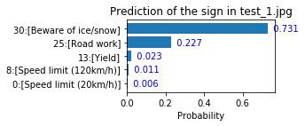

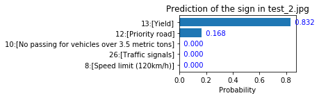

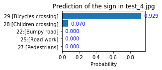

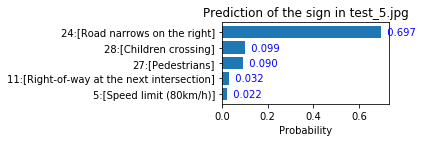

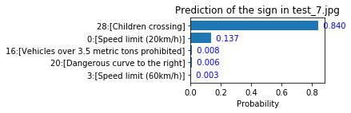

```python
for idx in range(len(top_k_values)):
    top_k_v = top_k_values[idx]
    top_k_idx = top_k_indices[idx]
    img_name = img_key_list_prob[idx]
    #
    draw_prediction_bar(top_k_v, top_k_idx, img_name)
```

### Project Writeup

Once you have completed the code implementation, document your results in a project writeup using this [template](https://github.com/udacity/CarND-Traffic-Sign-Classifier-Project/blob/master/writeup_template.md) as a guide. The writeup can be in a markdown or pdf file.

## Step 4 (Optional): Visualize the Neural Network's State with Test Images

This Section is not required to complete but acts as an additional excersise for understaning the output of a neural network's weights. While neural networks can be a great learning device they are often referred to as a black box. We can understand what the weights of a neural network look like better by plotting their feature maps. After successfully training your neural network you can see what it's feature maps look like by plotting the output of the network's weight layers in response to a test stimuli image. From these plotted feature maps, it's possible to see what characteristics of an image the network finds interesting. For a sign, maybe the inner network feature maps react with high activation to the sign's boundary outline or to the contrast in the sign's painted symbol.

Provided for you below is the function code that allows you to get the visualization output of any tensorflow weight layer you want. The inputs to the function should be a stimuli image, one used during training or a new one you provided, and then the tensorflow variable name that represents the layer's state during the training process, for instance if you wanted to see what the LeNet lab's feature maps looked like for it's second convolutional layer you could enter conv2 as the tf_activation variable.

For an example of what feature map outputs look like, check out NVIDIA's results in their paper [End-to-End Deep Learning for Self-Driving Cars](https://devblogs.nvidia.com/parallelforall/deep-learning-self-driving-cars/) in the section Visualization of internal CNN State. NVIDIA was able to show that their network's inner weights had high activations to road boundary lines by comparing feature maps from an image with a clear path to one without. Try experimenting with a similar test to show that your trained network's weights are looking for interesting features, whether it's looking at differences in feature maps from images with or without a sign, or even what feature maps look like in a trained network vs a completely untrained one on the same sign image.

[figure not shown]

Your output should look something like this (above)

```python
### Visualize your network's feature maps here.
### Feel free to use as many code cells as needed.

# image_input: the test image being fed into the network to produce the feature maps
# tf_activation: should be a tf variable name used during your training procedure that represents the calculated state of a specific weight layer
# activation_min/max: can be used to view the activation contrast in more detail, by default matplot sets min and max to the actual min and max values of the output
# plt_num: used to plot out multiple different weight feature map sets on the same block, just extend the plt number for each new feature map entry


def outputFeatureMap(image_input, tf_activation, activation_min=-1, activation_max=-1 ,plt_num=1):
    # Here make sure to preprocess your image_input in a way your network expects
    # with size, normalization, ect if needed
#     image_input = pre_processing(image_input)
    image_input = image_input.reshape((1, image_input.shape[0], image_input.shape[1], image_input.shape[2]))
    # Note: x should be the same name as your network's tensorflow data placeholder variable
    # If you get an error tf_activation is not defined it may be having trouble accessing the variable from inside a function
    activation = tf_activation.eval(session=sess,feed_dict={x : image_input})
    featuremaps = activation.shape[3]
    plt.figure(plt_num, figsize=(15,15))
    for featuremap in range(featuremaps):
        plt.subplot(6,8, featuremap+1) # sets the number of feature maps to show on each row and column
        plt.title('FeatureMap ' + str(featuremap)) # displays the feature map number
        if activation_min != -1 & activation_max != -1:
            plt.imshow(activation[0,:,:, featuremap], interpolation="nearest", vmin =activation_min, vmax=activation_max, cmap="gray")
        elif activation_max != -1:
            plt.imshow(activation[0,:,:, featuremap], interpolation="nearest", vmax=activation_max, cmap="gray")
        elif activation_min !=-1:
            plt.imshow(activation[0,:,:, featuremap], interpolation="nearest", vmin=activation_min, cmap="gray")
        else:
            plt.imshow(activation[0,:,:, featuremap], interpolation="nearest", cmap="gray")
#     plt.suptitle("a")
```

```
INFO:tensorflow:Restoring parameters from ./lenet
```

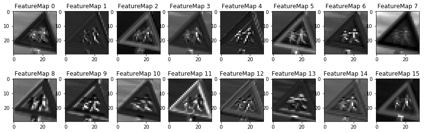

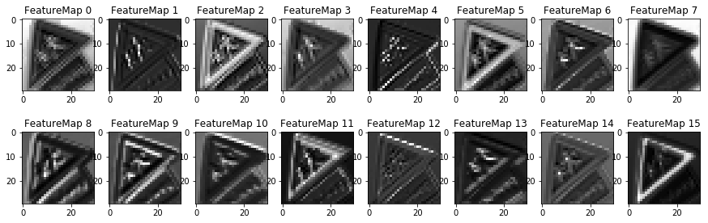

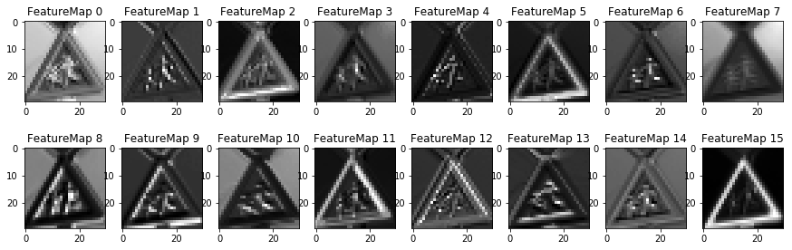

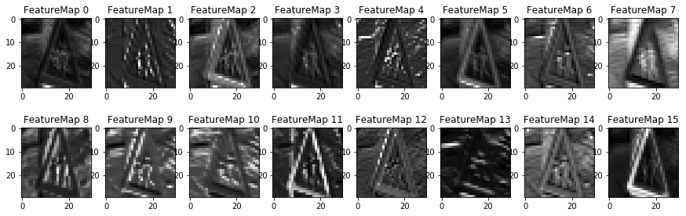

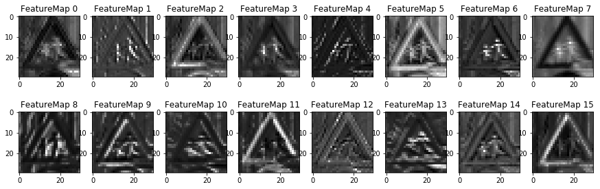

```python
sess = tf.InteractiveSession()
sess.as_default()
saver.restore(sess, tf.train.latest_checkpoint('.'))
#
key_list = sorted(list(img_x_dict.keys()))
for idx, key in enumerate(key_list):
    outputFeatureMap(img_x_dict[key], layer_dict["conv1_a"], plt_num=idx)
#
sess.close()
```